# Study of weather harmful events in US (1950-2011)

José Manuel Peñas

19 de mayo de 2018

## Synopsis

The following document studies the data recorded by the **US National Weather Service** of relevant weather events in the period **1950-2011**.  
It analyses those events grouping by types and obtains which ones have caused more **human** and **economic** losses. The study concludes that:

- **TORNADOS** are the most harmful events from the **human** perspective with more than **96,000** casualties, deaths and injured.
- **FLOODS** are the events that provokes heaviest **economic** losses with more than **$150 billions** on damage in the period to **property** and **agriculture**.

## Data Processing

From the **US National Weather Service** I have got a file with data recorded about the weather events, storms, since **1950** to November of **2011**.  
The data for this assignment come in the form of a comma-separated-value file compressed via the **bzip2** algorithm to reduce its size. You can download the file from the course web [site](https://d396qusza40orc.cloudfront.net/repdata%2Fdata%2FStormData.csv.bz2).  
The information about the variables of the file can be consulted on the following links:

- National Weather Service [Storm Data Documentation](https://d396qusza40orc.cloudfront.net/repdata%2Fpeer2_doc%2Fpd01016005curr.pdf)
- National Climatic Data Center Storm Events [FAQ](https://d396qusza40orc.cloudfront.net/repdata%2Fpeer2_doc%2FNCDC%20Storm%20Events-FAQ%20Page.pdf)

### KNTIR Setup

```r
require(knitr)
```

```r
require(ggplot2)
require(dplyr)
options(scipen = 999)
knitr::opts_chunk$set(echo = TRUE)
```

### Download & dataset creation

Downloading the file from **National Web Service** [link](https://d396qusza40orc.cloudfront.net/repdata%2Fdata%2FStormData.csv.bz2) and reading the **bz2** file with *read.csv* and storing it at a data frame.

```r
if(!file.exists("./data/StormData.csv.bz2"))
        download.file(
        "https://d396qusza40orc.cloudfront.net/repdata%2Fdata%2FStormData.csv.bz2",
        "./data/StormData.csv.bz2"
        )
        storms = read.csv("./data/StormData.csv.bz2", stringsAsFactors = F
        )
```

Checking the right size and format of the data set

```r
dim(storms)
```

```
## [1] 902297     37
```

```r
head(storms)
```

```
##   STATE__           BGN_DATE BGN_TIME TIME_ZONE COUNTY COUNTYNAME STATE
## 1       1  4/18/1950 0:00:00     0130       CST     97     MOBILE    AL
## 2       1  4/18/1950 0:00:00     0145       CST      3    BALDWIN    AL
## 3       1  2/20/1951 0:00:00     1600       CST     57    FAYETTE    AL
## 4       1   6/8/1951 0:00:00     0900       CST     89    MADISON    AL
## 5       1 11/15/1951 0:00:00     1500       CST     43    CULLMAN    AL
## 6       1 11/15/1951 0:00:00     2000       CST     77 LAUDERDALE    AL
##    EVTYPE BGN_RANGE BGN_AZI BGN_LOCATI END_DATE END_TIME COUNTY_END
## 1 TORNADO         0                                               0
## 2 TORNADO         0                                               0
## 3 TORNADO         0                                               0
## 4 TORNADO         0                                               0
## 5 TORNADO         0                                               0
## 6 TORNADO         0                                               0
##   COUNTYENDN END_RANGE END_AZI END_LOCATI LENGTH WIDTH F MAG FATALITIES
```

[output cut: 20 more lines]

The data set has **902,297** observations of **37** variables.

### Analysis of the dataset

After checking the data set and questions to answer, I have reached to the following conclusions:

- I only need a **fraction** of the columns
- So the economic as the human impact have to be processed cause the information is stored in **two columns** in both cases, **damage** and **exp factor**.
- I need to obtain the **totals** of economic and human damage grouped **by type of event**.

### Simplifying the dataset

Creating a new data set with only *type of event, injuries, fatalities* and *economic damage** columns.

```r
processedStorms = storms[, c(
        "EVTYPE",
        "FATALITIES",
        "INJURIES",
        "PROPDMG",
        "PROPDMGEXP",
        "CROPDMG",
        "CROPDMGEXP"
        )]
# Checking the new dataset contains the information I want
dim(processedStorms)
```

```
## [1] 902297      7
```

```r
head(processedStorms)
```

```
##    EVTYPE FATALITIES INJURIES PROPDMG PROPDMGEXP CROPDMG CROPDMGEXP
## 1 TORNADO          0       15    25.0          K       0
## 2 TORNADO          0        0     2.5          K       0
## 3 TORNADO          0        2    25.0          K       0
## 4 TORNADO          0        2     2.5          K       0
## 5 TORNADO          0        2     2.5          K       0
## 6 TORNADO          0        6     2.5          K       0
```

### Creating Total Human and economic damage columns

Human damage is stored in two columns *FATALITIES* and *INJURIES*. They are going to be joined in only one, adding both. I am not sure if both columns should be **treated equally** as a death is more severe than a injured but as I don’t know how to measure this severity, I’d rather to keep it simple.

```r
processedStorms$HumanDmg = processedStorms$FATALITIES + processedStorms$INJURIES
# Checking the new dataset contains the information I want
dim(processedStorms)
```

```
## [1] 902297      8
```

```r
head(processedStorms)
```

```
##    EVTYPE FATALITIES INJURIES PROPDMG PROPDMGEXP CROPDMG CROPDMGEXP
## 1 TORNADO          0       15    25.0          K       0
## 2 TORNADO          0        0     2.5          K       0
## 3 TORNADO          0        2    25.0          K       0
## 4 TORNADO          0        2     2.5          K       0
## 5 TORNADO          0        2     2.5          K       0
## 6 TORNADO          0        6     2.5          K       0
##   HumanDmg
## 1       15
## 2        0
## 3        2
## 4        2
## 5        2
## 6        6
```

Economic Damage is stored in four columns *PROPDMG, PROPDMGEXP,CROPDMG* and *CROPDMGEXP* that represent the property and crop damage with their multiplying factors.  
Checking the values stored on the multiplying columns,

```r
unique(processedStorms$PROPDMGEXP)
```

```
##  [1] "K" "M" ""  "B" "m" "+" "0" "5" "6" "?" "4" "2" "3" "h" "7" "H" "-"
## [18] "1" "8"
```

```r
unique(processedStorms$CROPDMGEXP)
```

```
## [1] ""  "M" "K" "m" "B" "?" "0" "k" "2"
```

it’s clear their content are not as correct as the documentation says.  
I create the following function that will transform the content of the **EXP** columns into the right number to be multiplied for.

```r
multFact <- function (fact){
        mult = 10^0
        # Numeric factors as exponents on 10 base
        if (is.numeric(fact))
                mult = 10^fact
        # American billions
        else if (fact == "B" | fact =="b") {
                mult = 10^9
        }
        # Millions
        else if (fact == "M" | fact =="m") {
                mult = 10^6
        }
        # Thousands
        else if (fact == "K" | fact =="K") {
                mult = 10^3
        }
        # Hundreds
        else if (fact == "H" | fact =="h") {
                mult = 10^2
        }
        # The rest of values are considered as wrong ones
        else{
                mult =10^0}
        mult
}
```

All this information is going to be stored in only one column in order to ease the study.

```r
# Getting Multiplying value
PropExpValues = sapply(processedStorms$PROPDMGEXP, FUN = multFact)
CropExpValues = sapply(processedStorms$CROPDMGEXP, FUN = multFact)
# Loading the result of multiplying the dmg for its factor
processedStorms$EconDmg = (processedStorms$PROPDMG*PropExpValues) + (processedStorms$CROPDMG*CropExpValues)
# Checking the new dataset contains the information I want
dim(processedStorms)
```

[output not shown]

```r
head(processedStorms)
```

[output not shown]

### Creating DataSet with totals by event type

```r
totalStorms = processedStorms %>%  group_by(EVTYPE) %>% summarise(
        HumanDamage = sum(HumanDmg, na.rm = T),
        EconomicDamage = sum(EconDmg, na.rm = T)
)
# Checking the new dataset contains the information I want
dim(totalStorms)
```

```
## [1] 985   3
```

```r
head(totalStorms)
```

```
## # A tibble: 6 x 3
##   EVTYPE                  HumanDamage EconomicDamage
##   <fct>                         <dbl>          <dbl>
## 1 "   HIGH SURF ADVISORY"           0         200000
## 2 " COASTAL FLOOD"                  0              0
## 3 " FLASH FLOOD"                    0          50000
## 4 " LIGHTNING"                      0              0
## 5 " TSTM WIND"                      0        8100000
## 6 " TSTM WIND (G45)"                0           8000
```

The resulting data set has **985** different event type and it’s impossible getting graphical conclusions with so many types. It should be necessary to reduce these types to the ones reflected on the [documentation](https://d396qusza40orc.cloudfront.net/repdata%2Fpeer2_doc%2Fpd01016005curr.pdf) but that table cannot be loaded by script and would invalidate the reproducible research of my peers.  
Therefore, two new data sets are going to be created with the **Top 10 Events** of both categories: human and economic damage.

```r
humanTop10 = totalStorms[, c("EVTYPE", "HumanDamage")] %>% top_n(10, HumanDamage) %>% arrange(desc(HumanDamage))
EconomicTop10  = totalStorms[, c("EVTYPE", "EconomicDamage")] %>% top_n(10, EconomicDamage) %>% arrange(desc(EconomicDamage))
# Checking the two new datasets contain the information I want
humanTop10
```

```
## # A tibble: 10 x 2
##    EVTYPE            HumanDamage
##    <fct>                   <dbl>
##  1 TORNADO                 96979
##  2 EXCESSIVE HEAT           8428
##  3 TSTM WIND                7461
##  4 FLOOD                    7259
##  5 LIGHTNING                6046
##  6 HEAT                     3037
##  7 FLASH FLOOD              2755
##  8 ICE STORM                2064
##  9 THUNDERSTORM WIND        1621
## 10 WINTER STORM             1527
```

```r
EconomicTop10
```

```
## # A tibble: 10 x 2
##    EVTYPE            EconomicDamage
##    <fct>                      <dbl>
##  1 FLOOD              150319678257
##  2 HURRICANE/TYPHOON   71913712800
##  3 TORNADO             57352114049.
##  4 STORM SURGE         43323541000
##  5 HAIL                18757805433.
##  6 FLASH FLOOD         17562129167.
##  7 DROUGHT             15018672000
##  8 HURRICANE           14610229010
##  9 RIVER FLOOD         10148404500
## 10 ICE STORM            8967041360
```

## Results

You can find the results to the two questions of this project under this section.  
It’s relevant to notice before showing the results that the event types should have been unified but as it was stated early, it could not be possible as there was not source that could be scripted.

### 1. Across the United States, which types of events (as indicated in the EVTYPE variable) are most harmful with respect to population health?

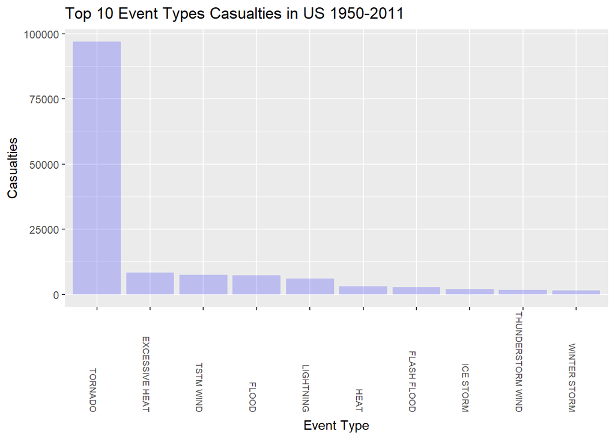

```r
ggplot(humanTop10, aes(x=reorder(EVTYPE,-HumanDamage), y=HumanDamage)) + geom_bar(stat="identity",fill = "blue",
        alpha = .2) + theme(axis.text.x = element_text(angle = 270, hjust = 1, size = 7)) + labs(title = "Top 10 Event Types Casualties in US 1950-2011", x = "Event Type", y = "Casualties")
```

As it can be observed in the figure, **TORNADOS** are the most human harmful weather events in the US. They have caused almost **100.000** total casualties, between fatalities and injured.

### 2. Across the United States, which types of events have the greatest economic consequences?

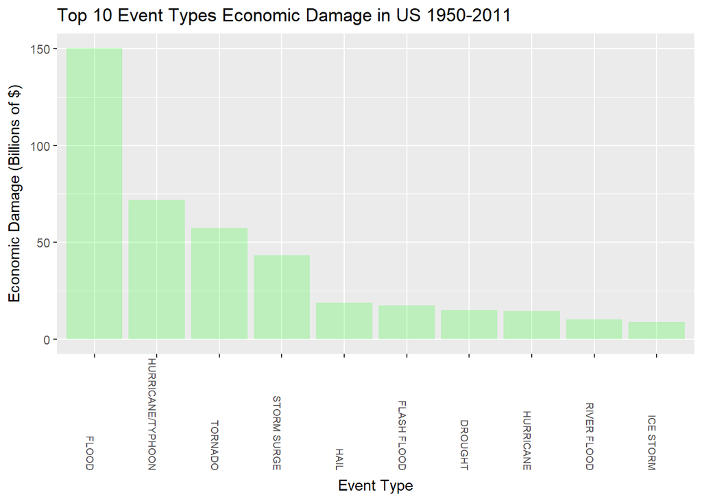

```r
ggplot(EconomicTop10, aes(x=reorder(EVTYPE,-EconomicDamage), y=EconomicDamage/10^9)) + geom_bar(stat="identity",fill = "green",
        alpha = .2) + theme(axis.text.x = element_text(angle = 270, hjust = 1, size = 7)) + labs(title = "Top 10 Event Types Economic Damage in US 1950-2011", x = "Event Type", y = "Economic Damage (Billions of $)")
```

**FLOODS** are the weather event with more economic impact, over **$150 billions** in losses, so property’s as crop’s damage. **HURRICANES & TYPHOONS** and **TORNADOS** follow in distant second and third place, with **71** and **57** billions.